# Review 3 | Data Analytics Project

### Reg. No: 18BCE1327

### Name: Mohammed Ali

### The Final Review

#### The global video game market size was valued at USD 151.06 billion in 2019 and is expected to grow at a Compound Annual Growth Rate (CAGR) of 12.9% from 2020 to 2027. Technological proliferation and innovation in both hardware and software are expected to be the key factors driving the growth. The growing penetration of internet services coupled with the easy availability and access of games on the internet across the globe is also expected to keep the market growth prospects upbeat in the forthcoming years. Game developers are also constantly improvising and pushing the technological limits regarding the real-time rendering of graphics in the video game industry, which is further expected to propel the growth.

### Aim

#### As we said before Video games are a multibillion dollar industry which aimes to grow in this analysis I want to show how the sales are affected by different factors such as Critic and User reviews and whether Good sales in one region are correleated to other regions.

## the dataset

```r
library("dplyr")
```

```r
library("ggplot2")
library("GGally")
library("tidyverse")
library("plotrix")
library("gridExtra")
library("grid")
library("lattice")
library("leaps")
library("data.table")
d2=read.csv('C:/Users/pc/Desktop/sem5/DATA PROJECT/data.csv')
d3 = d2%>%
  mutate(Rating=replace(Rating,Rating=="","E")) %>%
  mutate(Rating=replace(Rating,Rating=="K-A","E")) %>%
  mutate(Rating=replace(Rating,Rating=="RP","E10+"))  %>%
  mutate(Rating=replace(Rating,Rating=="AO","M"))
d3=na.omit(d3)
d4=read.csv('C:/Users/pc/Desktop/sem5/DATA PROJECT/ek.csv')
```

## Dataset Exploration

```r
colnames(d3)
```

```
##  [1] "Name"            "Platform"        "Year_of_Release" "Genre"
##  [5] "Publisher"       "NA_Sales"        "EU_Sales"        "JP_Sales"
##  [9] "Other_Sales"     "Global_Sales"    "Critic_Score"    "Critic_Count"
## [13] "User_Score"      "User_Count"      "Developer"       "Rating"
```

```r
str(d3)
```

```
## 'data.frame':    7017 obs. of  16 variables:
##  $ Name           : chr  "Wii Sports" "Mario Kart Wii" "Wii Sports Resort" "New Super Mario Bros." ...
##  $ Platform       : chr  "Wii" "Wii" "Wii" "DS" ...
##  $ Year_of_Release: chr  "2006" "2008" "2009" "2006" ...
##  $ Genre          : chr  "Sports" "Racing" "Sports" "Platform" ...
##  $ Publisher      : chr  "Nintendo" "Nintendo" "Nintendo" "Nintendo" ...
##  $ NA_Sales       : num  41.4 15.7 15.6 11.3 14 ...
##  $ EU_Sales       : num  28.96 12.76 10.93 9.14 9.18 ...
##  $ JP_Sales       : num  3.77 3.79 3.28 6.5 2.93 4.7 4.13 3.6 0.24 2.53 ...
##  $ Other_Sales    : num  8.45 3.29 2.95 2.88 2.84 2.24 1.9 2.15 1.69 1.77 ...
##  $ Global_Sales   : num  82.5 35.5 32.8 29.8 28.9 ...
##  $ Critic_Score   : int  76 82 80 89 58 87 91 80 61 80 ...
##  $ Critic_Count   : int  51 73 73 65 41 80 64 63 45 33 ...
##  $ User_Score     : chr  "8" "8.3" "8" "8.5" ...
##  $ User_Count     : int  322 709 192 431 129 594 464 146 106 52 ...
##  $ Developer      : chr  "Nintendo" "Nintendo" "Nintendo" "Nintendo" ...
##  $ Rating         : chr  "E" "E" "E" "E" ...
##  - attr(*, "na.action")= 'omit' Named int [1:9702] 2 5 6 10 11 13 19 21 22 23 ...
##   ..- attr(*, "names")= chr [1:9702] "2" "5" "6" "10" ...
```

```r
summary(d3)
```

```
##      Name             Platform         Year_of_Release       Genre
##  Length:7017        Length:7017        Length:7017        Length:7017
##  Class :character   Class :character   Class :character   Class :character
##  Mode  :character   Mode  :character   Mode  :character   Mode  :character
##
##
##
##   Publisher            NA_Sales          EU_Sales          JP_Sales
##  Length:7017        Min.   : 0.0000   Min.   : 0.0000   Min.   :0.00000
##  Class :character   1st Qu.: 0.0600   1st Qu.: 0.0200   1st Qu.:0.00000
##  Mode  :character   Median : 0.1500   Median : 0.0600   Median :0.00000
##                     Mean   : 0.3893   Mean   : 0.2331   Mean   :0.06295
##                     3rd Qu.: 0.3900   3rd Qu.: 0.2100   3rd Qu.:0.01000
##                     Max.   :41.3600   Max.   :28.9600   Max.   :6.50000
##   Other_Sales        Global_Sales      Critic_Score    Critic_Count
##  Min.   : 0.00000   Min.   : 0.0100   Min.   :13.00   Min.   :  3.00
##  1st Qu.: 0.01000   1st Qu.: 0.1100   1st Qu.:62.00   1st Qu.: 14.00
##  Median : 0.02000   Median : 0.2900   Median :72.00   Median : 24.00
##  Mean   : 0.08153   Mean   : 0.7671   Mean   :70.25   Mean   : 28.78
##  3rd Qu.: 0.07000   3rd Qu.: 0.7500   3rd Qu.:80.00   3rd Qu.: 39.00
##  Max.   :10.57000   Max.   :82.5300   Max.   :98.00   Max.   :113.00
##   User_Score          User_Count       Developer            Rating
##  Length:7017        Min.   :    4.0   Length:7017        Length:7017
##  Class :character   1st Qu.:   11.0   Class :character   Class :character
##  Mode  :character   Median :   27.0   Mode  :character   Mode  :character
##                     Mean   :  173.4
##                     3rd Qu.:   89.0
##                     Max.   :10665.0
```

## Some more Exploratory Analysis

## Finding The Top publishers with Global sales

```r
TopPublishers=aggregate(d3$Global_Sales,list(d3$Publisher),sum)
TopPublishers= TopPublishers[with(TopPublishers, order(-x)), ]
head(TopPublishers, 10)
```

```
##                          Group.1      x
## 66               Electronic Arts 885.56
## 172                     Nintendo 851.02
## 10                    Activision 540.72
## 213  Sony Computer Entertainment 388.10
## 235         Take-Two Interactive 350.41
## 252                      Ubisoft 341.35
## 153       Microsoft Game Studios 216.49
## 244                          THQ 162.97
## 209                         Sega 152.01
## 132 Konami Digital Entertainment 139.54
```

#### The top 9/10 companies here are either from America or Japan, the only exception being Ubisoft which is from france. this shows how dominant Japan and USA are in the gaming industry.

## Top 10 developers

```r
Topdev=aggregate(d3$Global_Sales,list(d3$Developer),sum)
Topdev= Topdev[with(Topdev, order(-x)), ]
head(Topdev, 10)
```

```
##               Group.1      x
## 795          Nintendo 529.90
## 354         EA Sports 148.15
## 337         EA Canada 135.61
## 959    Rockstar North 119.47
## 206            Capcom 114.89
## 1195         Treyarch 103.00
## 1218 Ubisoft Montreal 102.05
## 1210          Ubisoft  94.65
## 358        EA Tiburon  87.14
## 568     Infinity Ward  77.56
```

## Top Publishers as per Number of games released

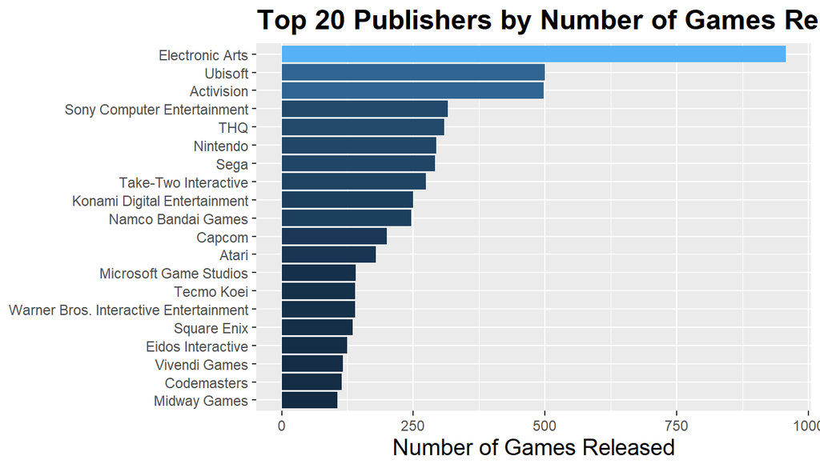

```r
pu=table(d3$Publisher)
pu=sort(pu,decreasing=TRUE)
pu=as.data.frame(pu)
colnames(pu)[1]<-"Publisher"
pub20=pu[1:20,]
vgpub=ggplot(pub20, aes(x=reorder(Publisher,Freq),y=Freq,fill=Freq)) + geom_bar(stat="identity") + coord_flip() + labs(x="Publishers", y="Number of Games Released", fill="Publisher",title="Top 20 Publishers by Number of Games Released") + theme(axis.title.x=element_text(size=14,face="plain"),axis.title.y=element_blank(),title = element_text(size=14,face="bold"),legend.position="none") + scale_fill_gradient()
vgpub
```

#### The American Company EA is winning by miles as its a very large company with many subsidaries

## Top Publishers as per Revenue

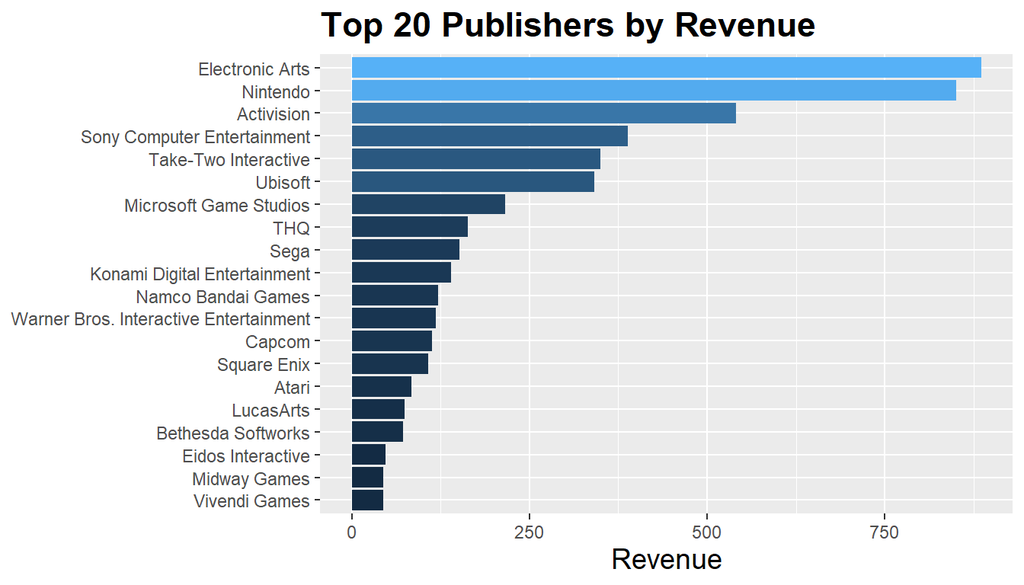

```r
vgrev=aggregate(Global_Sales~Publisher,d3,sum)
vgrev=vgrev[order(-vgrev$Global_Sales),]
rownames(vgrev)=1:nrow(vgrev)
vgrev20=vgrev[1:20,]
rev20=ggplot(vgrev20, aes(x=reorder(Publisher,Global_Sales),y=Global_Sales,fill=Global_Sales)) + geom_bar(stat="identity") + coord_flip() + labs(x="Publishers", y="Revenue",title="Top 20 Publishers by Revenue") + theme(legend.position="none",axis.title.y=element_blank(),axis.title.x=element_text(size=14,face="plain"),title = element_text(size=14,face="bold")) + scale_fill_gradient()
rev20
```

#### Here as well EA is leading but nintendo is not far behind as it not only makes games but also makes gaming consoles and has consolidated the japanese market

## Top Developers as per Number of games released

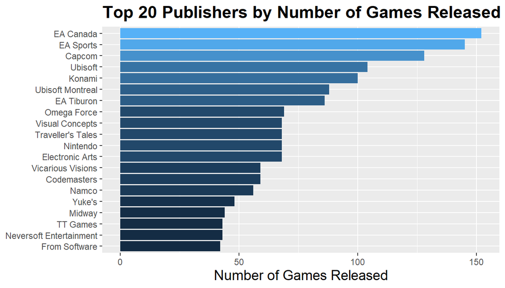

```r
re=table(d3$Developer)
re=sort(re,decreasing=TRUE)
re=as.data.frame(re)
colnames(re)[1]<-"Developer"
re2=re[1:20,]
ww1=ggplot(re2, aes(x=reorder(Developer,Freq),y=Freq,fill=Freq)) + geom_bar(stat="identity") + coord_flip() + labs(x="Publishers", y="Number of Games Released", fill="Developer",title="Top 20 Publishers by Number of Games Released") + theme(axis.title.x=element_text(size=14,face="plain"),axis.title.y=element_blank(),title = element_text(size=14,face="bold"),legend.position="none") + scale_fill_gradient()
ww1
```

## Top Developers as per Revenue

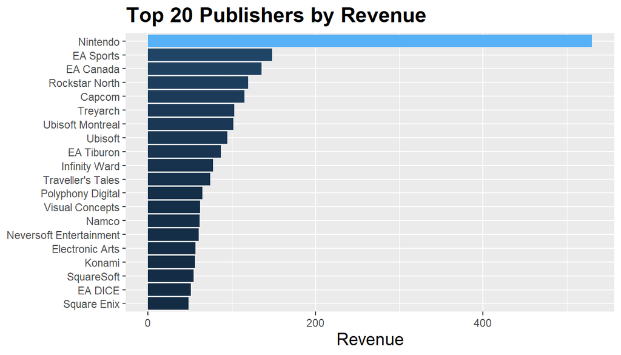

```r
lol=aggregate(Global_Sales~Developer,d3,sum)
lol=lol[order(-lol$Global_Sales),]
rownames(lol)=1:nrow(lol)
vgrev20=lol[1:20,]
ww2=ggplot(vgrev20, aes(x=reorder(Developer,Global_Sales),y=Global_Sales,fill=Global_Sales)) + geom_bar(stat="identity") + coord_flip() + labs(x="Publishers", y="Revenue",title="Top 20 Publishers by Revenue") + theme(legend.position="none",axis.title.y=element_blank(),axis.title.x=element_text(size=14,face="plain"),title = element_text(size=14,face="bold")) + scale_fill_gradient()
ww2
```

## Choosing the variable of interest - Rating

#### Each game upon release needs to be rated defining the restrictions on the age of the player, this is necessary as many games contain graphic content which is not suitable for younger children.

| Rating name : | Description: |
| --- | --- |
| `E` | Can be played by everyone |
| `M` | Mature Audience only, meaning 17 or older |
| `T` | For Teens and above |
| `E10+` | Everyone older than 10 years |

## Distribution of Ratings

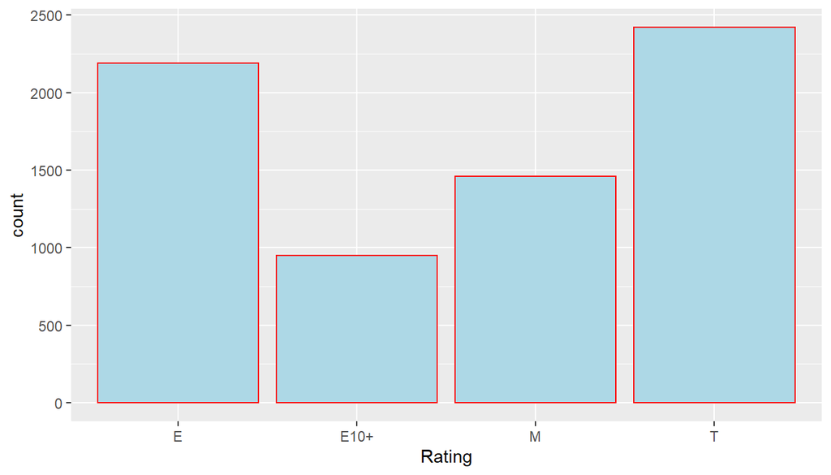

```r
ggplot(data=d3,aes(x=Rating))+geom_bar(fill="lightblue",col="red")
```

#### Majority lies when Mature and teen categories are combined, but games meant for everyone still have a significant majority

## Global sales with respect to critic score

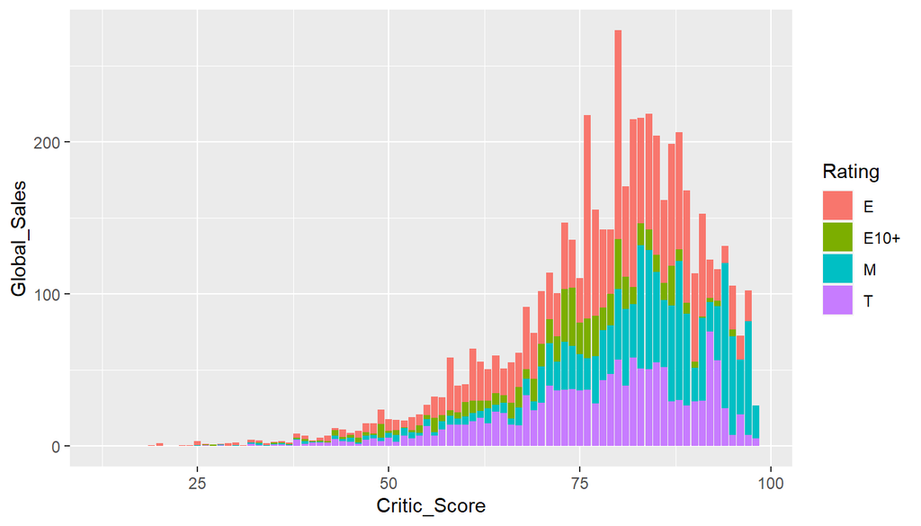

```r
ggplot(data=d3,aes(y=Global_Sales,x=Critic_Score,fill=Rating)) +geom_bar(stat="identity")
```

#### As we can see global sales of video games is actually somewhat correleated to the the critic score as the games with Critic scored less than 50 have significantly less sales.

## Global sales with respect to User score

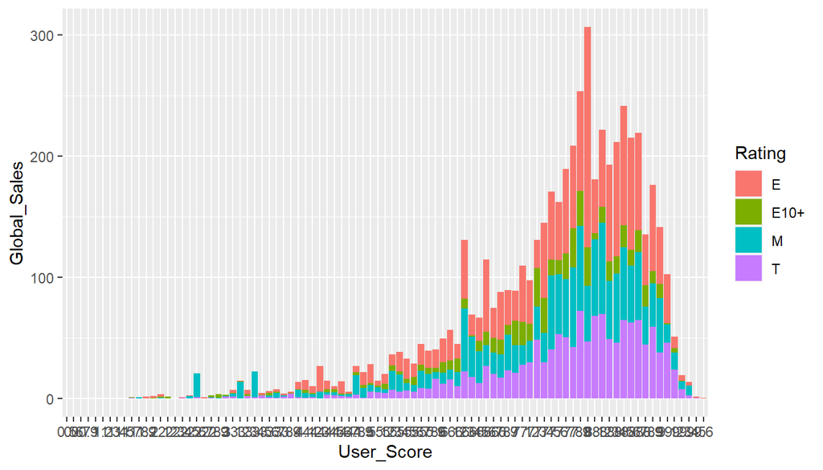

```r
ggplot(data=d3,aes(y=Global_Sales,x=User_Score,fill=Rating)) +geom_bar(stat = "identity")
```

#### here as well the user score did affect the global sales. and similarly games meant for ages more than 10 have a majority

## Are Sales Affected by critic and User rating?

```r
d5= filter(d4,is.na(User_Score) == FALSE,is.na(Critic_Score) == FALSE,is.na(Global_Sales) == FALSE)
genre_score=d5 %>% group_by(Genre) %>% summarize(Critic_Score = mean(Critic_Score,na.rm=TRUE),User_Score = mean(User_Score,na.rm=TRUE))
genre_score= pivot_longer(genre_score,cols=ends_with("Score"),names_to="Type",values_to="Score")
game_sales=d5 %>% group_by(Genre) %>% summarize(Global_Sales = mean(Global_Sales,na.rm=TRUE))
```

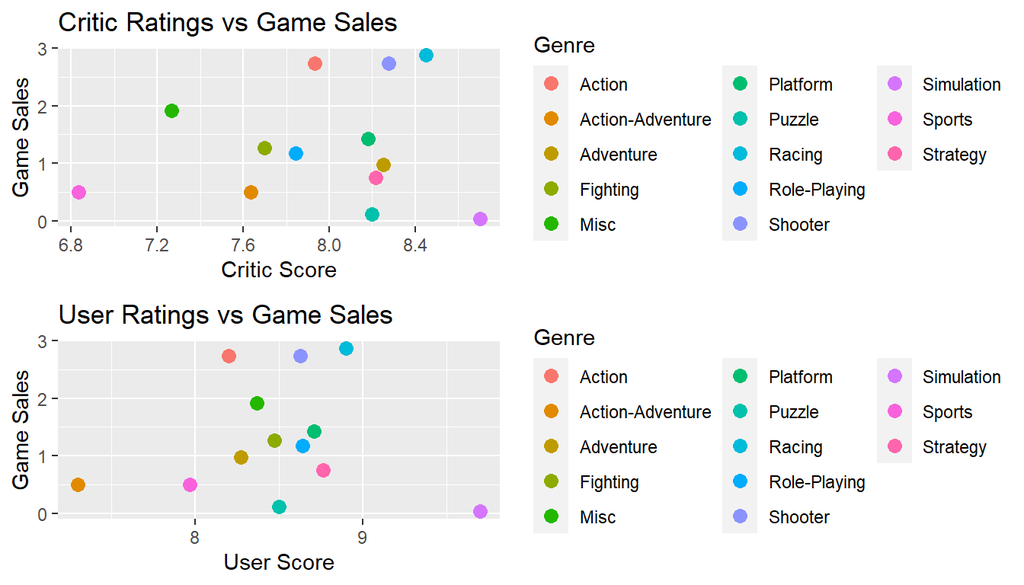

```r
sps =genre_score %>% merge(game_sales,by="Genre")
ssc = filter(drop_na(sps),Type == 'Critic_Score')
ssu= filter(drop_na(sps),Type == 'User_Score')


critic = ggplot(ssc,aes(fill=Genre,x=Score,y=Global_Sales,color=Genre)) + geom_point(size=3) + xlab("Critic Score") +   ylab("Game Sales") +   ggtitle("Critic Ratings vs Game Sales") +  guides(fill=guide_legend(ncol=3)) +   geom_jitter()

user =ggplot(ssu,aes(fill=Genre,x=Score,y=Global_Sales,color=Genre)) +   geom_point(size=3) +   xlab("User Score") +   ylab("Game Sales") +   ggtitle("User Ratings vs Game Sales") + guides(fill=guide_legend(ncol=3)) + geom_jitter()
grid.arrange(critic,user)
```

## Distribution of genre as per platform

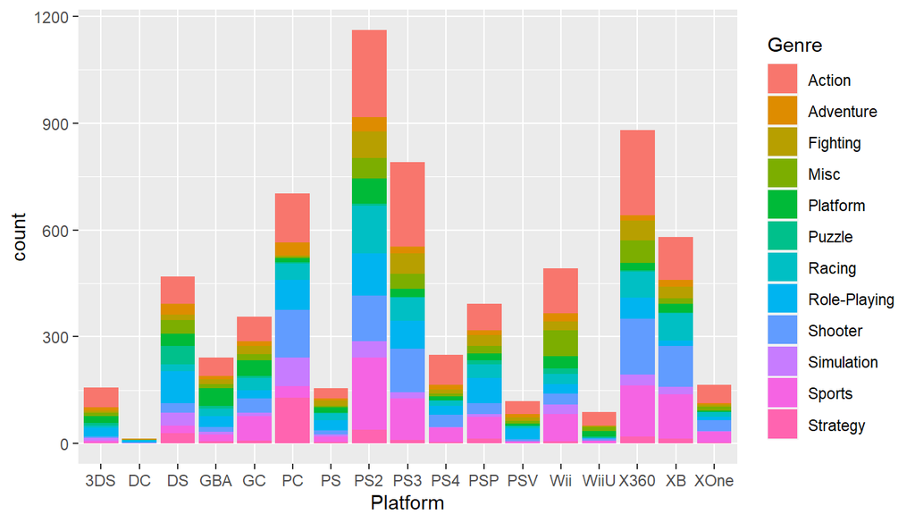

```r
ggplot(data=d3,aes(Platform,fill=Genre))+geom_bar()
```

## Distribution of ratings as per the category

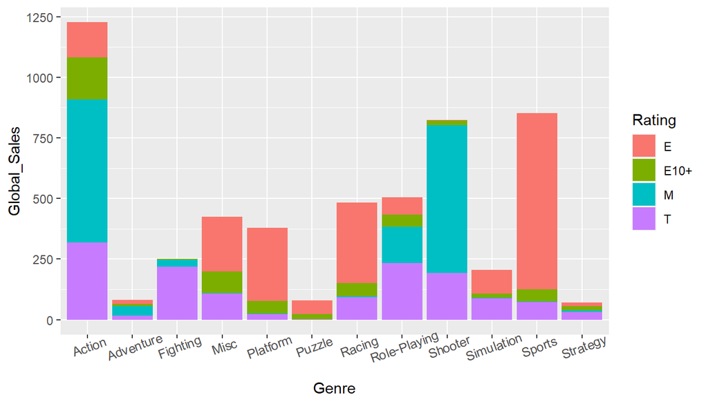

```r
ggplot(data=d3,aes(y=Global_Sales,x=Genre,fill=Rating))+geom_bar(stat = "identity")+theme(axis.text.x = element_text(angle = 20,size = 9))
```

#### We can clearly See that that in Shooter, Action And Fighting games Had majority in M and T rating where as Sports, Racing and Platform games Had majority in E and E10+ Rating

## Distribution of Regional Sales as per Global Sales

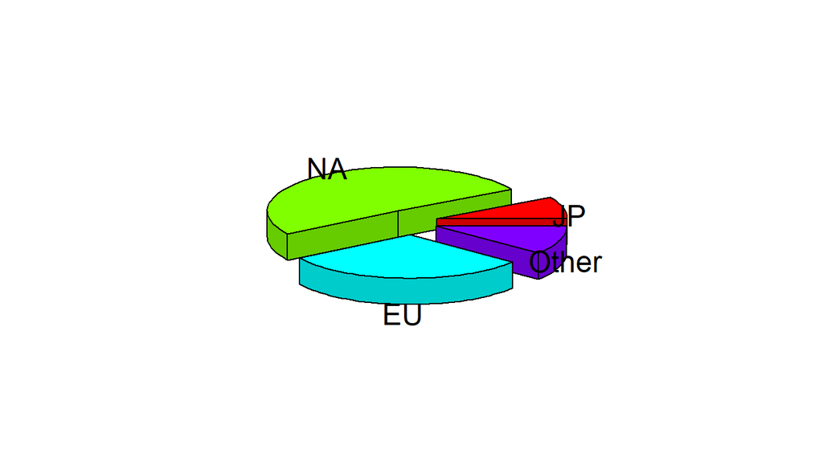

```r
EU_Sales=sum(d3$EU_Sales)
NA_Sales=sum(d3$NA_Sales)
JP_Sales=sum(d3$JP_Sales)
Other_Sales=sum(d3$Other_Sales)
Global_Sales=sum(d3$Global_Sales)
kk=data.frame(Global_Sales=c(JP_Sales,NA_Sales,EU_Sales,Other_Sales))
pie3D(kk$Global_Sales,explode=0.2,labels=c("JP","NA","EU","Other"))
```

#### Hence North america holds the major market share with over 50% due to being the location of the major companies

## Correlation graph of all variables

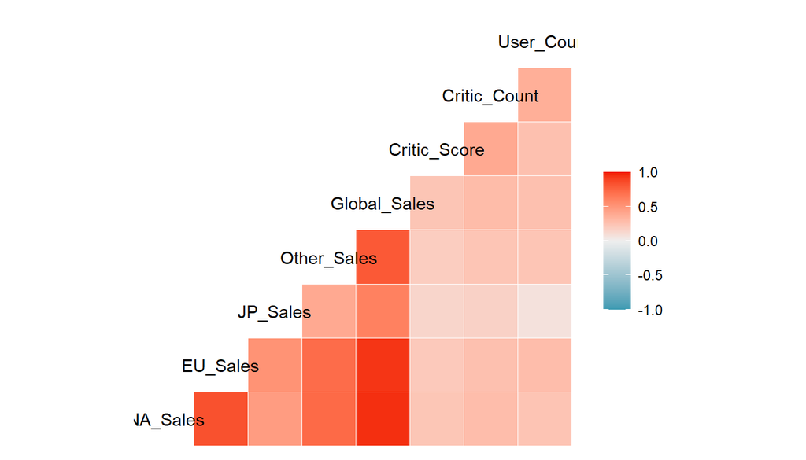

```r
ggcorr(d3)
```

## Correleation between global sales and North american sales

```r
cor(d3$Global_Sales,d3$NA_Sales,use="complete.obs")
```

```
## [1] 0.9554866
```

#### 0.955 indicates high correlation

## Linear regression model for relation between NA sales and EU sales

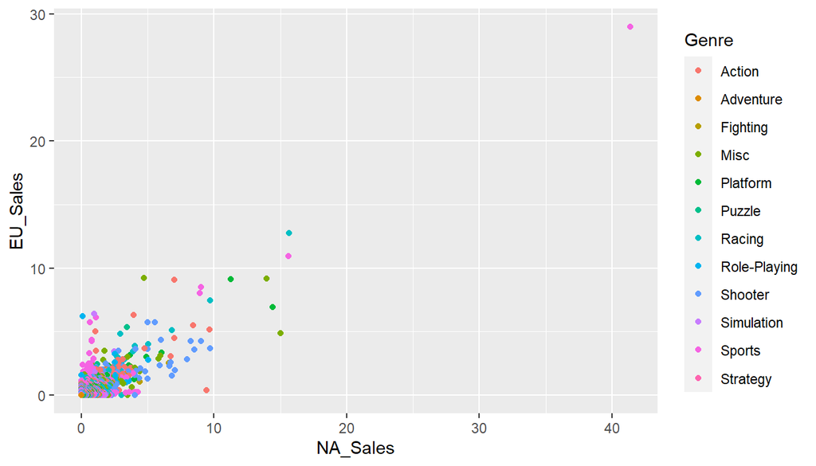

```r
ggplot(data=d3,aes(x=NA_Sales,y=EU_Sales,col=Genre))+geom_point(stat="identity")
```

```r
jkr=lm(EU_Sales~NA_Sales,data=d3)
klk=plot(EU_Sales~NA_Sales,data=d3)

summary(jkr)
```

```
##
## Call:
## lm(formula = EU_Sales ~ NA_Sales, data = d3)
##
## Residuals:
##     Min      1Q  Median      3Q     Max
## -5.2226 -0.0643 -0.0070  0.0355  6.3733
##
## Coefficients:
##             Estimate Std. Error t value Pr(>|t|)
## (Intercept) 0.001024   0.004750   0.216    0.829
## NA_Sales    0.596139   0.004598 129.665   <2e-16 ***
## ---
## Signif. codes:  0 '***' 0.001 '**' 0.01 '*' 0.05 '.' 0.1 ' ' 1
##
## Residual standard error: 0.3686 on 7015 degrees of freedom
## Multiple R-squared:  0.7056, Adjusted R-squared:  0.7056
## F-statistic: 1.681e+04 on 1 and 7015 DF,  p-value: < 2.2e-16
```

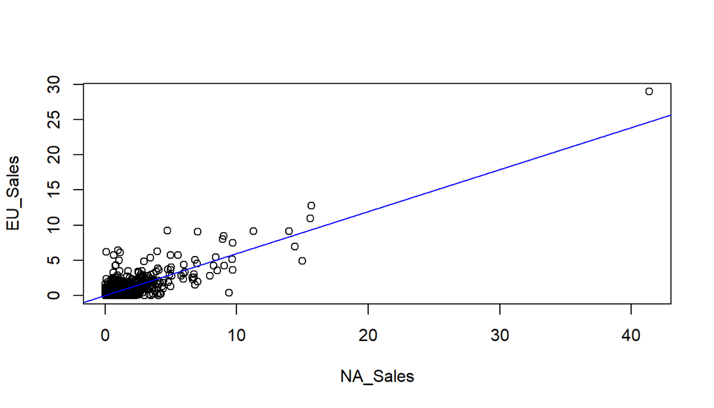

```r
abline(jkr,col="blue")
```

#### hence P- value is less than 0.05 and R-squared is 0.70 meaning NA sales can predict upto 70% of the EU sales

## Linear regression model for relation between NA sales and Other sales

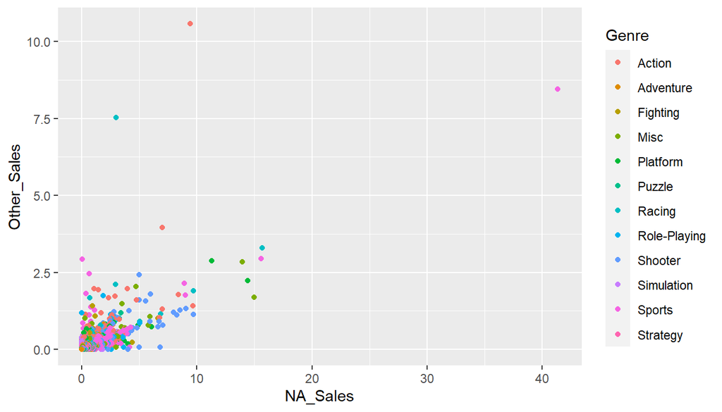

```r
ggplot(data=d3,aes(x=NA_Sales,y=Other_Sales,col=Genre))+geom_point(stat="identity")
```

```r
jkr4=lm(Other_Sales~NA_Sales,data=d3)
klk4=plot(Other_Sales~NA_Sales,data=d3)

summary(jkr4)
```

```
##
## Call:
## lm(formula = Other_Sales ~ NA_Sales, data = d3)
##
## Residuals:
##     Min      1Q  Median      3Q     Max
## -1.3509 -0.0233 -0.0067  0.0069  8.6573
##
## Coefficients:
##             Estimate Std. Error t value Pr(>|t|)
## (Intercept) 0.002674   0.002359   1.134    0.257
## NA_Sales    0.202550   0.002283  88.715   <2e-16 ***
## ---
## Signif. codes:  0 '***' 0.001 '**' 0.01 '*' 0.05 '.' 0.1 ' ' 1
##
## Residual standard error: 0.183 on 7015 degrees of freedom
## Multiple R-squared:  0.5287, Adjusted R-squared:  0.5287
## F-statistic:  7870 on 1 and 7015 DF,  p-value: < 2.2e-16
```

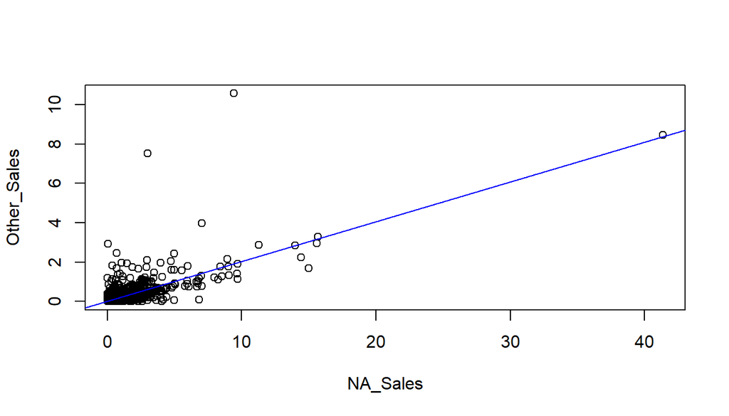

```r
abline(jkr4,col="blue")
```

#### Even though P value is less than 0.05 the residuals and R-squared suggests that Other sales are not very correleated to NA sales

## Linear regression model for relation between NA sales and JP sales

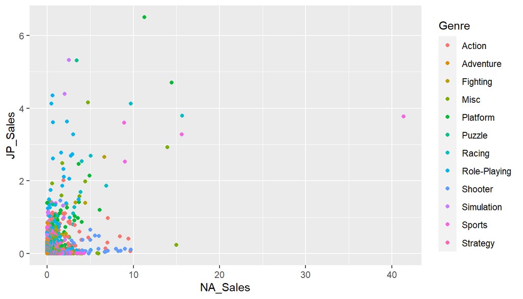

```r
ggplot(data=d3,aes(x=NA_Sales,y=JP_Sales,col=Genre))+geom_point(stat="identity")
```

```r
jkr1=lm(JP_Sales~NA_Sales,data=d3)
klk1=plot(JP_Sales~NA_Sales,data=d3)

summary(jkr1)
```

```
##
## Call:
## lm(formula = JP_Sales ~ NA_Sales, data = d3)
##
## Residuals:
##     Min      1Q  Median      3Q     Max
## -1.9755 -0.0478 -0.0214 -0.0090  4.9743
##
## Coefficients:
##             Estimate Std. Error t value Pr(>|t|)
## (Intercept) 0.008957   0.003238   2.766  0.00569 **
## NA_Sales    0.138698   0.003134  44.250  < 2e-16 ***
## ---
## Signif. codes:  0 '***' 0.001 '**' 0.01 '*' 0.05 '.' 0.1 ' ' 1
##
## Residual standard error: 0.2513 on 7015 degrees of freedom
## Multiple R-squared:  0.2182, Adjusted R-squared:  0.2181
## F-statistic:  1958 on 1 and 7015 DF,  p-value: < 2.2e-16
```

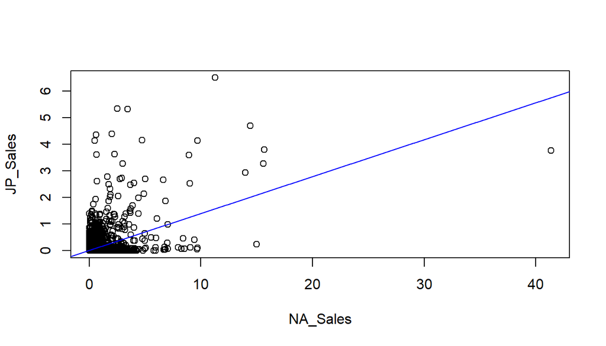

```r
abline(jkr1,col="blue")
```

#### Even though P value is less than 0.05 the residuals and R-squared suggests that JP sales are not correleated to NA sales

## Looking at why Japan is different from the other regions

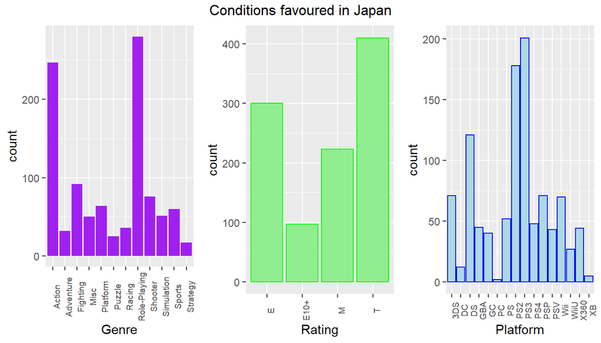

```r
q1=mean(d3$JP_Sales)
q2=mean(d3$NA_Sales)
q3=mean(d3$EU_Sales)
q4=mean(d3$Other_Sales)
qq1=d3[which(d3$JP_Sales>q1),]
qq2=d3[which(d3$NA_Sales>q2),]
qq3=d3[which(d3$EU_Sales>q3),]
qq4=d3[which(d3$Other_Sales>q4),]

w1=ggplot(qq1,aes(x=Genre))+geom_bar(fill="purple")+theme(axis.text.x = element_text(angle = 90,size = 7))
w2=ggplot(qq1,aes(Rating))+geom_bar(fill="light green",col="green")+theme(axis.text.x = element_text(angle = 90,size = 7))
w3=ggplot(qq1,aes(Platform))+geom_bar(fill="light blue",col="blue")+theme(axis.text.x = element_text(angle = 90,size = 7))

w21=ggplot(qq2,aes(Genre))+geom_bar(fill="purple")+theme(axis.text.x = element_text(angle = 90,size = 7))
w22=ggplot(qq2,aes(Rating))+geom_bar(fill="light green",col="green")+theme(axis.text.x = element_text(angle = 90,size = 7))
w23=ggplot(qq2,aes(Platform))+geom_bar(fill="light blue",col="blue")+theme(axis.text.x = element_text(angle = 90,size = 7))

w31=ggplot(qq3,aes(Genre))+geom_bar(fill="purple")+theme(axis.text.x = element_text(angle = 90,size = 7))
w32=ggplot(qq3,aes(Rating))+geom_bar(fill="light green",col="green")+theme(axis.text.x = element_text(angle = 90,size = 7))
w33=ggplot(qq3,aes(Platform))+geom_bar(fill="light blue",col="blue")+theme(axis.text.x = element_text(angle = 90,size = 7))

w41=ggplot(qq4,aes(Genre))+geom_bar(fill="purple")+theme(axis.text.x = element_text(angle = 90,size = 7))
w42=ggplot(qq4,aes(Rating))+geom_bar(fill="light green",col="green")+theme(axis.text.x = element_text(angle = 90,size = 7))
w43=ggplot(qq4,aes(Platform))+geom_bar(fill="light blue",col="blue")+theme(axis.text.x = element_text(angle = 90,size = 7))

grid.arrange(w1,w2,w3,nrow=1,top="Conditions favoured in Japan")
```

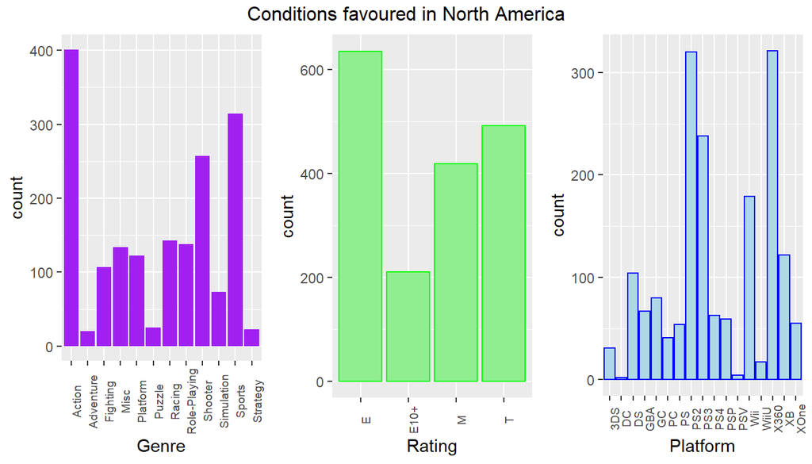

```r
grid.arrange(w21,w22,w23,nrow=1,top="Conditions favoured in North America")
```

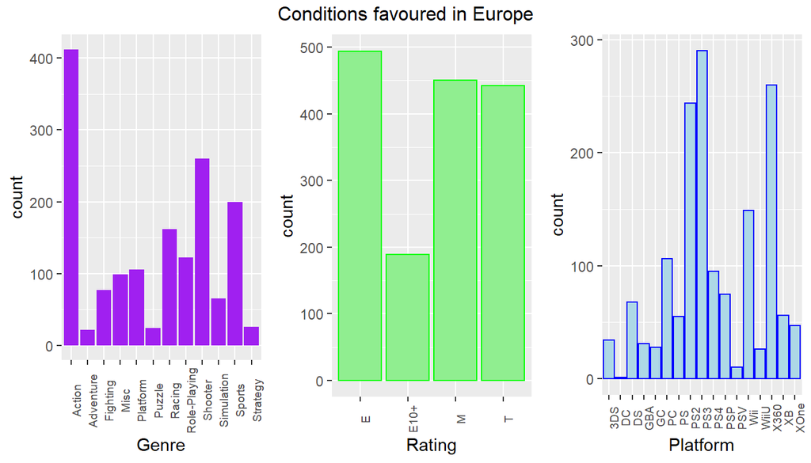

```r
grid.arrange(w31,w32,w33,nrow=1,top="Conditions favoured in Europe")
```

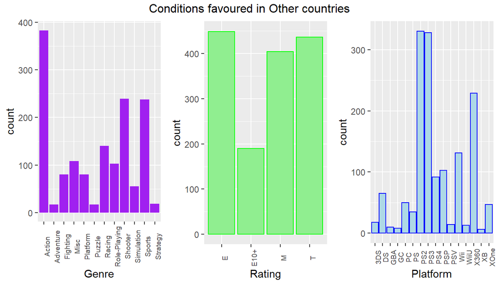

```r
grid.arrange(w41,w42,w43,nrow=1,top="Conditions favoured in Other countries")
```